# Brazil's Marketplace in Motion

### A data story of the Olist e-commerce ecosystem (2016–2018)

**Dataset:** [Brazilian E-Commerce Public Dataset by Olist](https://www.kaggle.com/datasets/olistbr/brazilian-ecommerce) — 100k real orders placed across Olist's multi-seller marketplace, spanning order status, price, payments, freight, customer & seller geolocation, products, and customer reviews. Sourced directly from Olist's own GitHub repository (`olist/work-at-olist-data`), an official mirror of the Kaggle release.

**Why this dataset:** it is real commercial data (anonymised), genuinely rich (9 linked tables, 45+ usable fields after merging), and varied — numerical (price, freight, weight), categorical (product category, payment type, state), spatial (customer/seller state & zip), and temporal (order timestamps 2016–2018).

**Structure of this notebook:**

1. Data loading & preliminary EDA
2. 12 analytical questions, each answered with one publication-ready Plotly visualization
3. Summary of key takeaways

```python
import pandas as pd
import numpy as np
import plotly.express as px
import plotly.graph_objects as go
import plotly.io as pio
from plotly.subplots import make_subplots

pd.set_option("display.max_columns", 50)
pio.renderers.default = "png"   # static, high-res images so the notebook renders identically in Jupyter, HTML and PDF exports
pio.kaleido.scope.default_scale = 2

# ---- CVD-safe palette (Okabe-Ito) -----------------------------------
GREY      = "#B0B0B0"   # muted context
HIGHLIGHT = "#0072B2"   # focus blue
ACCENT2   = "#D55E00"   # vermillion (secondary highlight)
ACCENT3   = "#009E73"   # bluish green
ACCENT4   = "#E69F00"   # orange
CVD_SEQ   = ["#0072B2", "#56B4E9", "#009E73", "#E69F00", "#D55E00", "#CC79A7", "#F0E442"]

TEMPLATE = "plotly_white"

def style(fig, title, height=460, width=900):
    fig.update_layout(
        template=TEMPLATE,
        title=dict(text=title, font=dict(size=17, family="Arial", color="#222"), x=0.02, xanchor="left"),
        font=dict(family="Arial", size=13, color="#333"),
        height=height, width=width,
        margin=dict(t=70, l=60, r=40, b=60),
        plot_bgcolor="white", paper_bgcolor="white",
        legend=dict(bgcolor="rgba(0,0,0,0)"),
    )
    fig.update_xaxes(showgrid=False, zeroline=False)
    fig.update_yaxes(showgrid=True, gridcolor="#EDEDED", zeroline=False)
    return fig
```

## 1 · Load data

Using the pre-merged master table (see `prepare_data.py` in this folder for the full merge/clean pipeline across the 9 raw Olist tables).

```python
items = pd.read_parquet("../data/master_items.parquet")
delivered = pd.read_parquet("../data/delivered_items.parquet")   # delivered orders only (needed for delivery-time analysis)
customers_summary = pd.read_parquet("../data/customers_summary.parquet")

print(f"{items.shape[0]:,} order-items | {items['order_id'].nunique():,} orders | "
      f"{items['customer_unique_id'].nunique():,} unique customers | "
      f"{items['seller_id'].nunique():,} sellers | {items['product_category_name_english'].nunique()} product categories")
items.head(3)
```

```
112,650 order-items | 98,666 orders | 95,420 unique customers | 3,095 sellers | 72 product categories
```

|  | order_id | order_item_id | product_id | seller_id | shipping_limit_date | price | freight_value | customer_id | order_status | order_purchase_timestamp | order_approved_at | order_delivered_carrier_date | order_delivered_customer_date | order_estimated_delivery_date | customer_unique_id | customer_zip_code_prefix | customer_city | customer_state | product_category_name_english | product_weight_g | product_length_cm | product_height_cm | product_width_cm | seller_zip_code_prefix | seller_city | seller_state | total_payment_value | n_payment_types | max_installments | … |
| --- | --- | --- | --- | --- | --- | --- | --- | --- | --- | --- | --- | --- | --- | --- | --- | --- | --- | --- | --- | --- | --- | --- | --- | --- | --- | --- | --- | --- | --- | --- |
| 0 | 00010242fe8c5a6d1ba2dd792cb16214 | 1 | 4244733e06e7ecb4970a6e2683c13e61 | 48436dade18ac8b2bce089ec2a041202 | 2017-09-19 09:45:35 | 58.9 | 13.29 | 3ce436f183e68e07877b285a838db11a | delivered | 2017-09-13 08:59:02 | 2017-09-13 09:45:35 | 2017-09-19 18:34:16 | 2017-09-20 23:43:48 | 2017-09-29 | 871766c5855e863f6eccc05f988b23cb | 28013 | campos dos goytacazes | RJ | cool_stuff | 650.0 | 28.0 | 9.0 | 14.0 | 27277 | volta redonda | SP | 72.19 | 1.0 | 2.0 | … |
| 1 | 00018f77f2f0320c557190d7a144bdd3 | 1 | e5f2d52b802189ee658865ca93d83a8f | dd7ddc04e1b6c2c614352b383efe2d36 | 2017-05-03 11:05:13 | 239.9 | 19.93 | f6dd3ec061db4e3987629fe6b26e5cce | delivered | 2017-04-26 10:53:06 | 2017-04-26 11:05:13 | 2017-05-04 14:35:00 | 2017-05-12 16:04:24 | 2017-05-15 | eb28e67c4c0b83846050ddfb8a35d051 | 15775 | santa fe do sul | SP | pet_shop | 30000.0 | 50.0 | 30.0 | 40.0 | 3471 | sao paulo | SP | 259.83 | 1.0 | 3.0 | … |
| 2 | 000229ec398224ef6ca0657da4fc703e | 1 | c777355d18b72b67abbeef9df44fd0fd | 5b51032eddd242adc84c38acab88f23d | 2018-01-18 14:48:30 | 199.0 | 17.87 | 6489ae5e4333f3693df5ad4372dab6d3 | delivered | 2018-01-14 14:33:31 | 2018-01-14 14:48:30 | 2018-01-16 12:36:48 | 2018-01-22 13:19:16 | 2018-02-05 | 3818d81c6709e39d06b2738a8d3a2474 | 35661 | para de minas | MG | furniture_decor | 3050.0 | 33.0 | 13.0 | 33.0 | 37564 | borda da mata | MG | 216.87 | 1.0 | 5.0 | … |

## 2 · Preliminary Exploratory Data Analysis

A quick look at shape, missingness, and single-variable summaries before moving to the analytical questions (these are exploratory only — not counted among the 12 questions below).

```python
items.dtypes.value_counts()
```

```
str               16
float64           15
datetime64[us]     7
int64              3
int32              2
bool               2
Name: count, dtype: int64
```

```python
items.isna().mean().sort_values(ascending=False).head(10).round(3)
```

```
order_delivered_customer_date    0.022
delivery_delay_days              0.022
delivery_days                    0.022
order_delivered_carrier_date     0.011
review_creation_date             0.008
review_score                     0.008
product_width_cm                 0.000
product_length_cm                0.000
product_weight_g                 0.000
product_height_cm                0.000
dtype: float64
```

```python
items[['price','freight_value','item_total','review_score']].describe().round(2)
```

|  | price | freight_value | item_total | review_score |
| --- | --- | --- | --- | --- |
| count | 112650.00 | 112650.00 | 112650.00 | 111708.00 |
| mean | 120.65 | 20.03 | 140.69 | 4.03 |
| std | 183.63 | 16.02 | 190.76 | 1.39 |
| min | 0.85 | 0.00 | 6.08 | 1.00 |
| 25% | 39.90 | 13.08 | 55.23 | 4.00 |
| 50% | 74.99 | 16.27 | 92.36 | 5.00 |
| 75% | 134.90 | 21.15 | 157.95 | 5.00 |
| max | 6735.00 | 409.68 | 6929.31 | 5.00 |

```python
items['order_status'].value_counts()
```

```
order_status
delivered      110197
shipped          1185
canceled          542
invoiced          359
processing        357
unavailable         7
approved            3
Name: count, dtype: int64
```

```python
print("Date range:", items['order_purchase_timestamp'].min(), "to", items['order_purchase_timestamp'].max())
```

```
Date range: 2016-09-04 21:15:19 to 2018-09-03 09:06:57
```

## 3 · Analytical Questions

Each question below is multi-dimensional — relating variables, comparing groups, or tracking change over time/space — and answered with one dedicated, explanatory Plotly visualization.

### Q1 — How does average delivery time vary across Brazilian states, and does slower delivery come with lower customer satisfaction?

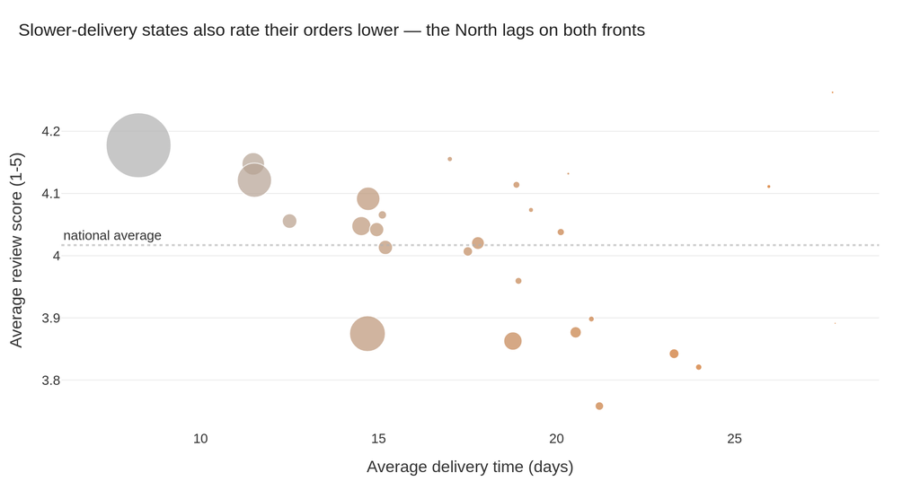

```python
state_perf = (delivered.groupby('customer_state', as_index=False)
              .agg(avg_delivery_days=('delivery_days','mean'),
                   avg_review=('review_score','mean'),
                   n_orders=('order_id','nunique'))
              .query('n_orders >= 30')
              .sort_values('avg_delivery_days'))

fig = px.scatter(state_perf, x='avg_delivery_days', y='avg_review', size='n_orders',
                  color='avg_delivery_days', color_continuous_scale=[GREY, ACCENT2],
                  hover_name='customer_state', size_max=45,
                  labels={'avg_delivery_days':'Average delivery time (days)','avg_review':'Average review score (1-5)'})
fig.update_traces(marker=dict(line=dict(width=1, color='white')))
fig.add_hline(y=state_perf['avg_review'].mean(), line_dash='dot', line_color=GREY, opacity=0.6,
              annotation_text='national average', annotation_position='top left')
fig = style(fig, "Slower-delivery states also rate their orders lower — the North lags on both fronts", height=480)
fig.update_coloraxes(showscale=False)
fig.show()
```

### Q2 — Which product categories drive the most revenue, and how has monthly revenue trended over 2017–2018?

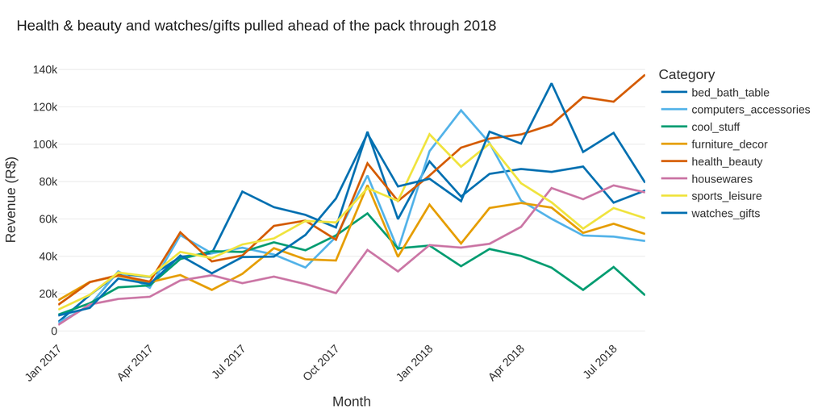

```python
top_cats = (items.groupby('product_category_name_english')['item_total'].sum()
            .sort_values(ascending=False).head(8).index)

monthly_cat = (items[items['product_category_name_english'].isin(top_cats) &
                      items['purchase_month'].between('2017-01','2018-08')]
               .groupby(['purchase_month','product_category_name_english'])['item_total']
               .sum().reset_index())

fig = px.line(monthly_cat, x='purchase_month', y='item_total', color='product_category_name_english',
              color_discrete_sequence=CVD_SEQ,
              labels={'purchase_month':'Month','item_total':'Revenue (R$)','product_category_name_english':'Category'})
fig.update_traces(line=dict(width=2.5))
fig = style(fig, "Health & beauty and watches/gifts pulled ahead of the pack through 2018", height=480, width=950)
fig.update_xaxes(tickangle=-45)
fig.show()
```

### Q3 — How does the freight-to-price ratio differ across product categories, and which categories are costliest to ship relative to their value?

[figure not shown]

```python
cat_freight = (delivered.groupby('product_category_name_english')
               .agg(median_ratio=('freight_ratio','median'), n=('order_id','count'))
               .query('n >= 100').sort_values('median_ratio', ascending=False).head(12).reset_index())

fig = px.bar(cat_freight.sort_values('median_ratio'), x='median_ratio', y='product_category_name_english',
             orientation='h', color='median_ratio', color_continuous_scale=[GREY, HIGHLIGHT],
             labels={'median_ratio':'Median freight ÷ price', 'product_category_name_english':''})
fig = style(fig, "Bulky, low-value items like furniture & construction goods carry the heaviest relative freight cost", height=500)
fig.update_coloraxes(showscale=False)
fig.show()
```